# Notebook

## Milestone 1: Identification, Website, and ETL (Introduction):

#### Group Members: Arturo Altamirano

#### https://arturoaltamirano.github.io/arturoAltamirano/

### I would like to prove that there is an observable correlation between industrial production in a given region and cancer rates. There was a Tulane study (https://law.tulane.edu/news/tulane-study-louisianas-severe-air-pollution-linked-dozens-cancer-cases-each-year) published which implicated industrial production in the "Industrial Coridor" with elevated cancer risk.

### I plan to measure raw pollutants in the form of phosporus, nitrogen, sulfur and carbon dioxide as sampled from air and water samples, comparing these to the cancer incidence rates by county as recorded by the U.S Census.

# Goals:

### I would like to first investigate and uphold these claims, and then gain insight into the emprical relation between the two phenomena, to eventually develop a model capable of predicting health consequences of industrial sites given a few metrics as input (regression classification model).

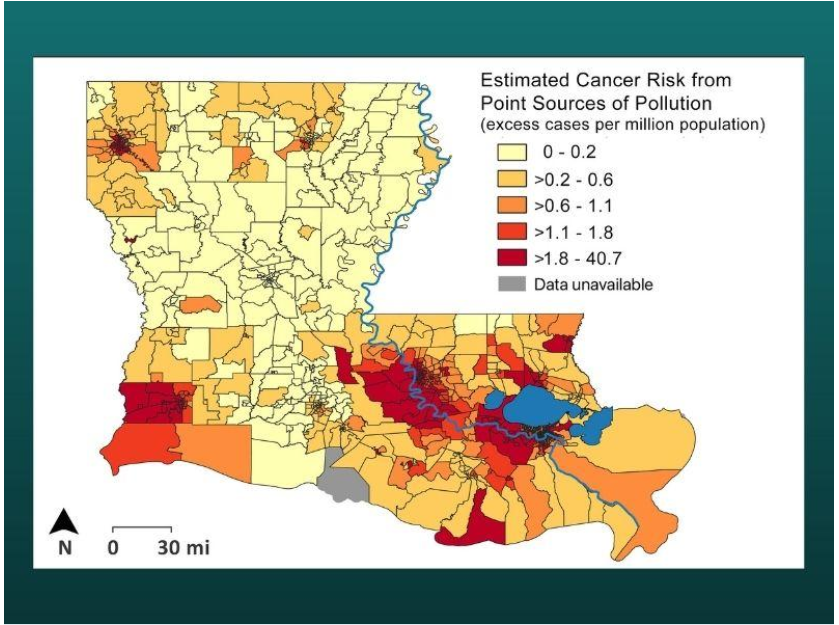

```python
import os
from IPython.display import Image

cwd = os.getcwd()

Image(os.path.join(cwd, 'media/tulaneStudy.png'))
```

# Louisiana Cancer Metrics

### What are the cancer rates within Louisiana, is there a noticeable disparity?

### I will be using the following dataset which has been sourced and minorly preproccessed from the United States Census Bureau's American Community Survey: https://data.world/exercises/linear-regression-exercise-1

### This dataset contains metrics pertaining to cancer rates and death rates by county. As well as some other details like poverty rates and average income.

### Aside: I will be using Geopy and Nominatim to create some pretty cool visuals, these are libraries/apis I had seen before but never used. I wanted to include them for this project.

### The shapefiles used to model the below maps are sourced from the United States Census Bureau: https://www.census.gov/geographies/mapping-files/time-series/geo/carto-boundary-file.html

### Note: You may notice some weird code about colab, I wanted to make this notebook runnable in colab/google drive in case you wished to download and run it yourself.

```python
#imports for data manipulation
import pandas as pd
import numpy as np
from tabulate import tabulate

#imports for data visualization
import matplotlib.pyplot as plt
import plotly.express as px
from shapely.geometry import Point

#geopandas and other geographic packages/libraries
import geopandas as gpd
from geopy.geocoders import Nominatim
from geopy.extra.rate_limiter import RateLimiter
from geopy.distance import geodesic
import zipfile

def state_countyMetrics(state_name, fips_code):
    '''takes a desired state and respective FIPS (Federal Information Processing Standard) code
       and returns a merged GeoPandas frame containing geospatial data
       and the cancer rates by county for the requested state


       we will use this frame for visualizing cnacer rates by county'''

    #get my data from the zip provided at the data source
    df_cancer_rates = pd.read_csv(os.path.join(cwd, 'data', 'county_zip_reg.csv'), encoding='latin1')

    #filter for only those whose county field (County, State) contains state_name
    filtered_df = df_cancer_rates[df_cancer_rates['County'].str.contains(state_name, case=False, na=False)]

    #we need to group these, as the cancer rates dataset contains many entries for a single county
    #I have chosen to average them, but any aggregation function may be used, or none at all
    countyTotals = filtered_df.groupby('County').agg({
        'incidenceRate': 'mean',
        'deathRate': 'mean',
        'avgDeathsPerYear': 'mean'}).reset_index()

    #drop the parish/county designation (Acadiana Parish -> Acadiana, Harris County -> Harris) to match other formats
    countyTotals['County'] = countyTotals['County'].str.split('Parish').str[0].str.strip()
    countyTotals['County'] = countyTotals['County'].str.split('County').str[0].str.strip()

    #prevent capitilization issues by forcing to capital
    countyTotals['County'] = countyTotals['County'].str.title()

    #each shapefile corresponds to a county
    with zipfile.ZipFile(os.path.join(cwd, "data/cb_2018_us_county_500k.zip"), "r") as zip_ref:
      zip_ref.extractall("county_shapefiles")

      #you can read these shapefiles using geopandas, this creates a 'GeoFrame' which is essentially a dataframe of metadata for a shapefile
      counties = gpd.read_file(os.path.join(cwd, 'county_shapefiles','cb_2018_us_county_500k.shp'), encoding='latin1')

    #get only the state we want according to FIPS code, this will return all surveyed counties
    la_counties = counties[counties['STATEFP'] == fips_code]

    #merge the cancer rates dataframe with our new GeoFrame, merging onto the geodata with our respective cancer metrics
    #the new frame is merged left and right on the County data from cancer dataset, and the NAME field for the geodata
    merged = la_counties.merge(countyTotals, left_on='NAME', right_on='County')

    #we now return our geodata, and respective cancer rates by county
    return merged

merged_Louisiana = state_countyMetrics('Louisiana','22')
```

```python
def incidence_plotter(merged, name, points_gdf):
    ''''pass the geoframe and individual desired points to highlight
        plots the incidence and death rate'''

    fig, (ax1, ax2) = plt.subplots(1, 2, figsize=(18, 8))

    merged.plot(column='incidenceRate', cmap='seismic', linewidth=0.8,
            ax=ax1, edgecolor='0.8', legend=True, aspect=1)

    ax1.set_title(f"Incidence Rate by County in {name}", fontsize=16)
    ax1.set_axis_off()

    merged.plot(column='deathRate', cmap='seismic', linewidth=0.8,
            ax=ax2, edgecolor='0.8', legend=True, aspect=1)

    ax2.set_title(f"Death Rate by County in {name}", fontsize=16)
    ax2.set_axis_off()

    try:
        points_gdf.plot(ax=ax1, color='black', markersize=100)
        points_gdf.plot(ax=ax2, color='black', markersize=100)

    except:
        return

    plt.show()
```

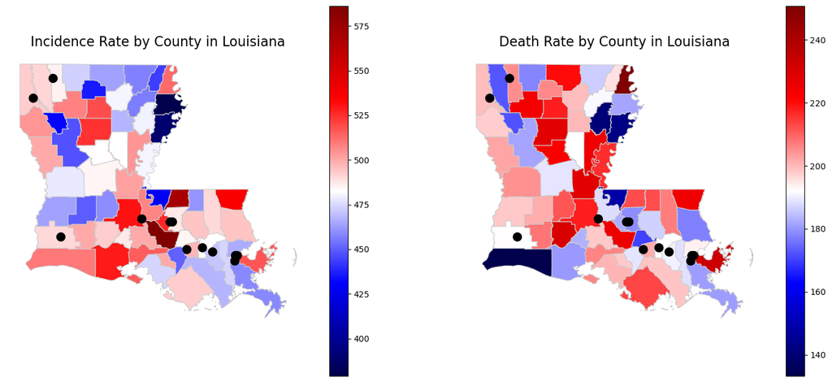

```python
#points of petrochemical refineries - https://www.industryselect.com/blog/top-10-manufacturing-companies-in-louisiana
#it would be great if there was a dataset of these somewhere but I have been unable to find any
points_df = pd.DataFrame({
    'Latitude': [30.483988, 29.846726, 29.938748, 30.031041, 32.797383,
                 30.065276, 30.526713, 30.240865, 29.933837,  29.995503, 30.476733, 32.470366],

    'Longitude': [-91.169601, -89.991966, -89.970822, -90.897768, -93.415004,
                  -90.593545, -91.746182, -93.272194, -89.944371, -90.409877, -91.210874, -93.789677],

    'Label': ['Baton Rouge Refinery', 'Alliance Refinery', 'Chalmette Refinery', 'Convent Refinery', 'Cotton Valley Refinery',
              'Garyville Refinery','Delek Refinery', 'Phillips 66 Lake Charles', 'Meraux Valero', 'Shell Norco',
              'Placid Refinery Port Allen', 'Calumet Shreveport']})

#convert lat/lon to Point geometry using shapely.point
geometry = [Point(xy) for xy in zip(points_df['Longitude'], points_df['Latitude'])]

#create another geodataframe out of these points
points_gdf = gpd.GeoDataFrame(points_df, geometry=geometry, crs='EPSG:4326')

incidence_plotter(merged_Louisiana, 'Louisiana', points_gdf)
```

# Noticeable concentration

#### It seems as though the conclusions drawn by the Tulane study are quantifiable with actual data. Notice the concentration of red regions near the Missisipi River in central Louisiana.

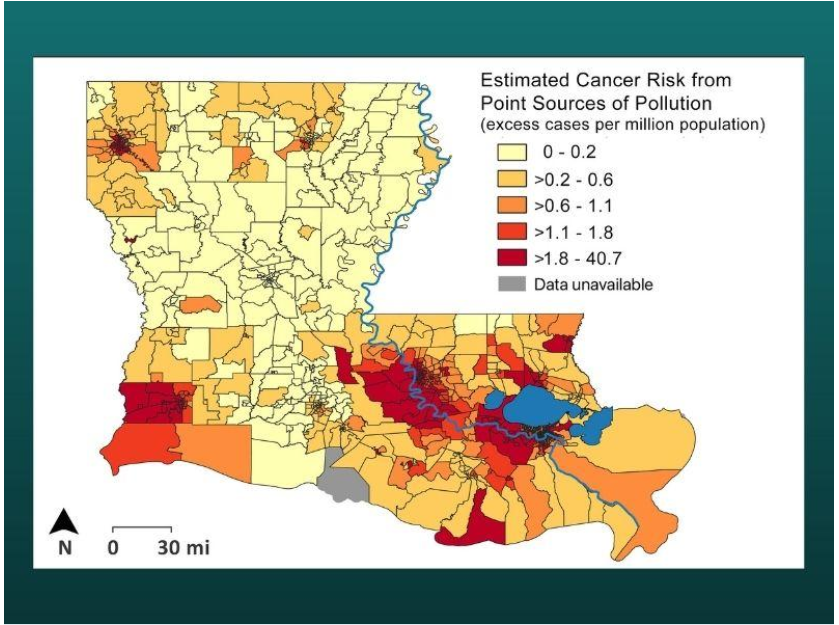

```python
Image(os.path.join(cwd, 'media/tulaneStudy.png'))
```

# What about Regional Metrics?

### Can we gain insight into the disparities between states? Or the general south?

#### I compiled this list by simply googling 'Petrochemical Plants in Louisiana' and 'Manufacturing Facilities in Texas'. There were a few sources compiled by third parties, but not any official sources listing them all that could be properly scrapped in a reliable manner.

#### I compiled the lat long coordinates by hand, entering the address of each plant to a lat/long service online.

#### You can google these plants provided to verify them, but I can assure you these are the largest plants in the state, or at the very least the only ones that come on google.

```python
#points of industrial facilities - https://www.industryselect.com/blog/top-10-manufacturing-companies-in-texas
#points of petrochemical refineries - https://www.arnolditkin.com/blog/plant-accidents/comprehensive-list-of-refineries-in-texas/
points_df = pd.DataFrame({
    'Latitude': [30.483988, 29.846726, 29.938748, 30.031041, 32.797383, 30.065276, 30.526713, 30.240865, 29.933837,  29.995503, 30.476733, 32.470366,

                 30.228790, 32.770222, 30.400474, 29.710871, 30.064680, 32.250530, 35.658669, 29.763359
                 ],

    'Longitude': [-91.169601, -89.991966, -89.970822, -90.897768, -93.415004, -90.593545, -91.746182, -93.272194, -89.944371, -90.409877, -91.210874, -93.789677,

                  -97.619720, -97.447731, -97.661238, -95.117630, -94.075760, -101.462578, -101.406662, -95.101273

                  ],

    #same as above, only now we are adding some more points in texas
    'Label': ['Baton Rouge Refinery', 'Alliance Refinery', 'Chalmette Refinery', 'Convent Refinery', 'Cotton Valley Refinery',
              'Garyville Refinery','Delek Refinery', 'Phillips 66 Lake Charles', 'Meraux Valero', 'Shell Norco', 'Placid Refinery Port Allen', 'Calumet Shreveport',

               #manufacturing plants and refineries in texas
              'Tesla Austin Plant', 'Lockheed Martin Plant', 'Dell Manufacturing Facility', 'Pemex-Shell Petrochemical Plant',
              'Beaumont Exxon Mobil Refinery', 'Delek Big Spring Refinery', 'Phillips 66 Borger Plant', 'Channelview LyondellBassel Petroleum Products Refinery',

              ]})

#convert lat/lon to Point geometry using shapely.point
geometry = [Point(xy) for xy in zip(points_df['Longitude'], points_df['Latitude'])]
points_gdf = gpd.GeoDataFrame(points_df, geometry=geometry, crs='EPSG:4326')

#kind of ugly to type this all out, but it will do
merged_Arizona = state_countyMetrics('Arizona', '04')
merged_Arkansas = state_countyMetrics('Arkansas', '05')
merged_NewMexico = state_countyMetrics('New Mexico', '35')
merged_Mississippi = state_countyMetrics('Mississippi', '28')
merged_Oklahoma = state_countyMetrics('Oklahoma','40')
merged_Texas = state_countyMetrics('Texas','48')
merged_Alabama = state_countyMetrics('Alabama', '01')
merged_Georgia = state_countyMetrics('Georgia', '13')
```

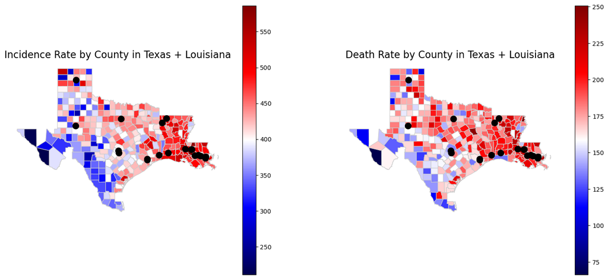

```python
#concatenate our geoframes together and plot
merged_tx_la = pd.concat([merged_Louisiana, merged_Texas])
incidence_plotter(merged_tx_la, 'Texas + Louisiana', points_gdf)
```

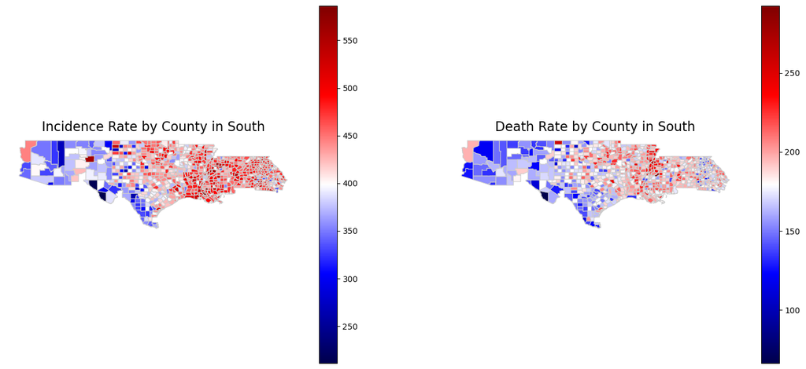

```python
merged_south = pd.concat([merged_Louisiana, merged_Texas, merged_NewMexico, merged_Arizona, merged_Oklahoma,
                          merged_Arkansas, merged_Mississippi, merged_Alabama, merged_Georgia])

#can pass None if you wish to not plot any points
incidence_plotter(merged_south, 'South', None)
```

# So, we can visually see a trend, but can we prove it empirically?

### What about corelation between proximity to plants and incidence rates? Income factors?

```python
df_cancer_rates = pd.read_csv(os.path.join(cwd, 'data', 'county_zip_reg.csv'), encoding='latin1')

def state_countyMetrics_single(state_name):
    '''a slightly altered version of the function above
       designed to only returned the grouped frame for requested state'''

    #get my data from the zip and from the pickle data
    df_cancer_rates = pd.read_csv(os.path.join(cwd, 'data', 'county_zip_reg.csv'), encoding='latin1')

    #filter for only those whose county field (County, State) contains state name
    filtered_df = df_cancer_rates[df_cancer_rates['County'].str.contains(state_name, case=False, na=False)]

    countyTotals = filtered_df.groupby('County').agg({
        'incidenceRate': 'mean',
        'deathRate': 'mean',
        'avgDeathsPerYear': 'mean',
        'povertyPercent': 'mean',
        'studyCount' : 'max',
        'medIncome' : 'mean',
        'popEst2015' : 'max'
    }).reset_index()

    countyTotals['County'] = countyTotals['County'].str.split('((7,9))').str[0].str.strip()

    #prevent capitilization issues by forcing to capital
    countyTotals['County'] = countyTotals['County'].str.title()

    return countyTotals

louisianaMetrics_df = state_countyMetrics_single('Louisiana')
```

```python
coordinates = list(zip(points_df['Latitude'], points_df['Longitude']))

def find_distance(county, coordinates):
    '''given a county and a set of coordinates, find the closest coordinate to the county'''
    try:
        #county lookup returns the lat lon coordinate of the county
        geolocator = Nominatim(user_agent="county_lookup")
        location = geolocator.geocode(county)

        lat, lon = (location.latitude, location.longitude)

        #for every coordinate provided, find the distance to the provided point
        distances = [geodesic((lat, lon), pt).miles for pt in coordinates]

        #return the distance to the closest industrial site
        return min(distances)

    except:
        #in the event a county cannot be translated (rare but it does happen)
        #return NaN to safely fill the slot in the geoframe
        return np.nan

louisianaMetrics_df["Min_Distance"] = np.nan

for index, row in louisianaMetrics_df.iterrows():
    #print(row['County'])
    louisianaMetrics_df.at[index, 'Min_Distance'] = find_distance(row['County'], coordinates)
```

# Empirical Results

#### Below we can see a slight inverse correlation between minimum distance to an industrial site and incidence rate. The further the minimum distance, the lower the rate.

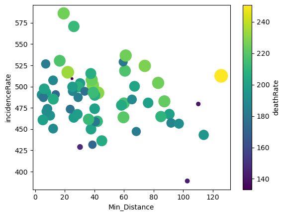

```python
from sklearn.preprocessing import MinMaxScaler
from sklearn.metrics import mean_absolute_error
from sklearn.neighbors import KNeighborsRegressor
from sklearn.model_selection import train_test_split
from sklearn.metrics import r2_score

def scatterplotter(x, y, z, df):
  '''pass desired gender and color to be scatterplotted'''

  resx = pd.Series(data = df[x])
  #print(res1)

  resy = pd.Series(data = df[y])
  #print(res2)

  resz = pd.Series(data = df[z])

  #had to min max scale sizes otherise they became massive and lost scale
  scaler = MinMaxScaler((10, 350))
  sizes = scaler.fit_transform(resz.values.reshape(-1, 1)).flatten()

  plt.scatter(resx, resy, s=sizes, c=resz)
  plt.xlabel(x)
  plt.ylabel(y)
  plt.colorbar(label=z)
  plt.show(),

scatterplotter('Min_Distance', 'incidenceRate', 'deathRate', louisianaMetrics_df)
```

```python
variables = ['Min_Distance',
             'incidenceRate',
             'deathRate']

louisianaMetrics_df[variables].corr()
```

|  | Min_Distance | incidenceRate | deathRate |
| --- | --- | --- | --- |
| Min_Distance | 1.000000 | -0.220154 | 0.107776 |
| incidenceRate | -0.220154 | 1.000000 | 0.428338 |
| deathRate | 0.107776 | 0.428338 | 1.000000 |

# The Disadvantaged

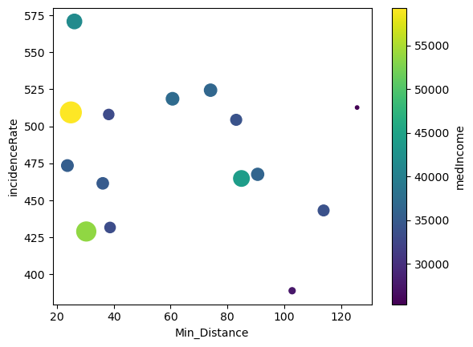

```python
under20 = louisianaMetrics_df.loc[louisianaMetrics_df['popEst2015'] < 20000]

scatterplotter('Min_Distance', 'incidenceRate', 'medIncome', under20)
```

```python
variables = ['Min_Distance',
             'incidenceRate',
             'medIncome']

under20[variables].corr()
```

|  | Min_Distance | incidenceRate | medIncome |
| --- | --- | --- | --- |
| Min_Distance | 1.000000 | -0.209968 | -0.559406 |
| incidenceRate | -0.209968 | 1.000000 | 0.256903 |
| medIncome | -0.559406 | 0.256903 | 1.000000 |

## Milestone 2: Expanded ETL

#### I will now bring in a pollution dataset measuring nitrogen and phosphorus from water samples. Nitrogen and Phosphorus are known in dicators of industrial pollution.

#### Acquired from Kaggle: https://www.kaggle.com/datasets/snmahsa/water-quality-and-sewage-system-dataset

#### Spoiler Alert: We're not going to be able to use these pollution datasets on a local scale for Louisiana for a reason we will see during exploration.

#### Even though our scope ends up being a limiting factor, this opens the door for future work, and we still preserve a way forward due to the size of one of our datasets.

```python
#get my data from the zip provided at the data source
df_water_pollution = pd.read_csv(os.path.join(cwd, 'data', 'water_pollution.csv'), encoding='latin1')

print(tabulate(df_water_pollution[:20],  headers ="keys", tablefmt="Github"))
```

```
      Geographical Location (Latitude)    Geographical Location (Longitude)  Sampling Date      Nitrogen (mg/L)    Phosphorus (mg/L)  State of Sewage System
--  ----------------------------------  -----------------------------------  ---------------  -----------------  -------------------  ------------------------
 0                            5.20109                             -55.0297   2022-06-10                 7.18186             2.32051   Good
 1                          -64.1964                               94.4833   2018-10-12                 9.73568             1.01531   Good
 2                           -7.89294                             -90.5031   2023-02-16                 6.77807             4.71845   Good
 3                          -11.3342                              110.779    2021-10-17                 3.3406              3.31571   Moderate
 4                          -24.5321                             -147.588    2021-12-01                 8.75321             4.68209   Good
 5                          -71.6319                               95.6539   2022-04-30                 9.78308             1.07626   Good
 6                           28.1393                             -108.145    2021-02-17                 7.95228             1.87188   Good
 7                           18.8722                             -155.313    2019-04-09                 3.47246             0.204054  Moderate
 8                          -36.6948                                2.41758  2015-07-28                 2.52899             2.17736   Moderate
 9                           13.6704                              167.377    2022-05-25                 1.77611             3.21834   Poor
10                           15.5723                              174.621    2022-04-13                 5.61866             4.92241   Moderate
11                           32.007                                68.4878   2022-01-09                 5.7913              1.39942   Good
12                           83.1939                             -109.729    2022-05-24                 9.7086              3.87264   Moderate
13                           81.4948                               -5.66697  2021-11-18                 3.88058             2.80699   Poor
14                           68.5986                             -153.752    2014-05-08                 8.78639             3.72885   Moderate
15                            0.238389                             21.4964   2018-10-22                 7.72558             2.85426   Good
16                           25.9182                               97.695    2022-08-27                 5.44343             3.69066   Moderate
17                          -36.3092                             -147.906    2023-03-12                 6.29329             1.86241   Good
18                           27.5761                              142.706    2022-09-15                 9.86133             4.55701   Moderate
19                           70.5462                               36.9651   2022-04-25                 5.61549             0.434013  Good
```

```python
def get_county(lat, lon):
    '''takes a latititude and longitude and returns the associated county attribute
       from geolocators reverse functionality'''

    #this try catch will keep our program from crashing if there is an error
    #nominatim is pretty reliable, but certain coordinates can cause unpredictable errors
    try:
        #we are going to interact with nominatim's api to locate our counties and plot to a visual
        geolocator = Nominatim(user_agent="geoapi")

        #geolocator.reverse or 'Reverse Geocoding' will return the nearest OSM (open street map) object to our provided lat lon coordinate
        location = geolocator.reverse((lat, lon), language='en', exactly_one=True, timeout=10)
        print(location)

        #if there is an 'address' element for our returned OSM object (this is a neccesary field - and almost all will have this)
        if 'address' in location.raw:
            address = location.raw['address']
            return address.get('county') or address.get('parish')

        else:
            return None

    except Exception as e:
        print(f"Error at ({lat},{lon}): {e}")
        return None
```

## Preprocessing

#### We need our shapefile data, and our pollution metrics. Right now the coordinates of the pollution measurements are in Lat/Lon format. We will use the above function, paired with the one below to first transcode from Lat/Lon to a parish, then join this onto our pollution measurements.

#### Essentially, finding out where the coordinates are will help us bin them to parishes, and will enable us to have a better understanding of the distribution this data represents in real space.

```python
def nitrogen_samples(df, fips_code, state_name):
    '''same as the stateCounty_metrics getter and plotter above, only modified to return the nitrogen
       phosphorus dataset for measuring pollution'''

    #get only data for our desired state
    df_state_nitrogen = df[df['State'].str.contains(state_name, case=False, na=False)].copy()

    #acquire county from the lat lon coordinates - use fancy lambda for list iteration and string indexing
    df_state_nitrogen.loc[:, 'County'] = df_state_nitrogen.apply(
    lambda row: get_county(row['Geographical Location (Latitude)'], row['Geographical Location (Longitude)']),
    axis=1)

    #this will be the same general structure as the prior milestone portion, only with this dataset
    #group all county entries together to get totals by county
    countyTotals = df_state_nitrogen.groupby('County').agg({
    'Nitrogen (mg/L)': 'mean',
    'Phosphorus (mg/L)': 'mean'
    }).reset_index()

    #could do some kind of evaluation here - but rather explicitly search for both in case it uses a parish system
    countyTotals['County'] = countyTotals['County'].str.split('Parish').str[0].str.strip()
    countyTotals['County'] = countyTotals['County'].str.split('County').str[0].str.strip()

    #avoid capitilization issues between strings
    countyTotals['County'] = countyTotals['County'].str.title()

    #print(countyTotals)

    with zipfile.ZipFile(os.path.join(cwd, "data/cb_2018_us_county_500k.zip"), "r") as zip_ref:
      zip_ref.extractall("county_shapefiles")

      counties = gpd.read_file(os.path.join(cwd, 'county_shapefiles','cb_2018_us_county_500k.shp'), encoding='latin1')

    state_counties = counties[counties['STATEFP'] == fips_code]

    merged = state_counties.merge(countyTotals, left_on='NAME', right_on='County', how='left')

    return merged
```

## Preprocessing

#### Now that we have our country data and have merged it onto our pollution data, we can plot this to it's respective parish and visualize it very nicely.

#### Please note, the dataframe presented below is the result of processing the entire dataset with the above functions. Essentially joining the measured pollutants with their latitiude/longitude metrics.

#### I removed the code used to drive these as it had large runtime - about 45 minutes. I did not want to leave a massive code block commented out so as to adhere to best principles.

```python
#these are all of the samples from every sampled county in the whole united states, store these in a pickle due to size
df_nitrogen_samples = pd.read_pickle('data/us_locations.pkl')

print(tabulate(df_nitrogen_samples[:10],  headers="keys", tablefmt="Github"))
```

```
       Geographical Location (Latitude)    Geographical Location (Longitude)  Sampling Date      Nitrogen (mg/L)    Phosphorus (mg/L)  State of Sewage System    State
---  ----------------------------------  -----------------------------------  ---------------  -----------------  -------------------  ------------------------  ----------
 14                             68.5986                            -153.752   2014-05-08                 8.78639             3.72885   Moderate                  Alaska
 34                             59.5887                            -157.373   2019-04-19                 3.74533             0.654298  Good                      Alaska
188                             56.4984                            -159.304   2023-10-18                 2.07447             1.54363   Moderate                  Alaska
240                             48.6231                            -116.798   2014-04-15                 7.06434             3.67552   Moderate                  Idaho
284                             42.8673                            -107.998   2015-09-30                 5.44716             4.47481   Moderate                  Wyoming
319                             62.9442                            -151.231   2014-05-07                 4.70128             1.27133   Good                      Alaska
342                             67.4716                            -150.367   2015-07-20                 6.08271             3.09048   Good                      Alaska
440                             60.8809                            -146.11    2023-07-15                 1.12781             2.10963   Poor                      Alaska
572                             34.337                             -104.681   2020-01-29                 9.08796             2.96908   Good                      New Mexico
612                             47.2921                             -88.9715  2019-01-04                 6.38455             4.27989   Good                      Michigan
```

## Ready to Visualize

#### Our Nitrogen_Samples function will provide our shapefile data for every given county within a state. It will also also merge for all our valid parishes the required shapefile polygons to be colored and plotted.

#### This table is hard to read, the last column is not meant to be interpreted by humans, but is neccesary for plotting visually with matplotlib.

```python
la_nitrogen = nitrogen_samples(df_nitrogen_samples, '22', 'LOUISIANA')
```

```
Hugh Mac Road, Evangeline Parish, Louisiana, 70586, United States
Harmon Road, Acadia Parish, Louisiana, United States
St. Tammany Parish, Louisiana, United States
Cameron Parish, Louisiana, United States
Hugh Mac Road, Evangeline Parish, Louisiana, 70586, United States
Harmon Road, Acadia Parish, Louisiana, United States
St. Tammany Parish, Louisiana, United States
Cameron Parish, Louisiana, United States
Hugh Mac Road, Evangeline Parish, Louisiana, 70586, United States
Harmon Road, Acadia Parish, Louisiana, United States
St. Tammany Parish, Louisiana, United States
Cameron Parish, Louisiana, United States
Hugh Mac Road, Evangeline Parish, Louisiana, 70586, United States
Harmon Road, Acadia Parish, Louisiana, United States
St. Tammany Parish, Louisiana, United States
Cameron Parish, Louisiana, United States
```

## Putting it all together...

```python
def nitrogen_plotter(merged):
    fig, (ax1, ax2) = plt.subplots(1, 2, figsize=(18, 8))

    merged.plot(column='Nitrogen (mg/L)', cmap='seismic', linewidth=0.8, ax=ax1,
            edgecolor='0.8', legend=True,
            missing_kwds={
                "color": "lightgrey",
                "edgecolor": "black",
                "hatch": "///",
                "label": "No data"
            })

    ax1.set_title("Nitrogen by County (m/g L)", fontsize=16)

    ax1.set_axis_off()

    merged.plot(column='Phosphorus (mg/L)', cmap='seismic', linewidth=0.8, ax=ax2,
            edgecolor='0.8', legend=True,
            missing_kwds={
                "color": "lightgrey",
                "edgecolor": "black",
                "hatch": "///",
                "label": "No data"
            })

    ax2.set_title('Phosphorus by County')
    ax2.axis('off')

    plt.tight_layout()
    plt.show()
```

```
      STATEFP    COUNTYFP    COUNTYNS  AFFGEOID          GEOID  NAME                LSAD       ALAND     AWATER  County      Nitrogen (mg/L)    Phosphorus (mg/L)  geometry
--  ---------  ----------  ----------  --------------  -------  ----------------  ------  ----------  ---------  --------  -----------------  -------------------  -----------------------------------------------------------------------------------------------------------------------------------------…
 0         22         001    00558389  0500000US22001    22001  Acadia                15  1696880710    5918557  Acadia              2.71859              0.33642  POLYGON ((-92.632291 30.317085, -92.629226 30.318001, -92.62843199999999 30.321118, -92.626662 30.319924999999998, -92.624302 30.319352, …
 1         22         009    00558424  0500000US22009    22009  Avoyelles             15  2154960192   87260913  nan               nan                  nan        POLYGON ((-92.280738 30.965071, -92.216911 30.965017, -92.21618699999999 30.96509, -92.214963 30.965667999999997, -92.213769 30.963555999…
 2         22         011    00558436  0500000US22011    22011  Beauregard            15  2997555226   21945878  nan               nan                  nan        POLYGON ((-93.73827299999999 30.403962999999997, -93.735626 30.406855999999998, -93.734892 30.408338999999998, -93.73480599999999 30.4092…
 3         22         029    00558515  0500000US22029    22029  Concordia             15  1805172278  130329989  nan               nan                  nan        POLYGON ((-91.86742199999999 31.316187, -91.866878 31.321316999999997, -91.867165 31.330651999999997, -91.866339 31.335943999999998, -91.…
 4         22         031    00558521  0500000US22031    22031  De Soto               15  2269875385   47052491  nan               nan                  nan        POLYGON ((-94.042681 32.137955999999996, -94.04268090893439 32.1379763794581, -94.042591 32.158097, -94.04253899999999 32.166826, -94.042…
 5         22         033    00558530  0500000US22033    22033  East Baton Rouge      15  1179330896   38571931  nan               nan                  nan        POLYGON ((-91.31648799999999 30.590003, -91.315282 30.594288, -91.30991399999999 30.601297, -91.301863 30.609496999999998, -91.2946499999…
 6         22         047    00558582  0500000US22047    22047  Iberville             15  1602243610   88655983  nan               nan                  nan        POLYGON ((-91.70093299999999 30.497432999999997, -91.625112 30.496957, -91.58337 30.497004999999998, -91.58365599999999 30.48259, -91.556…
 7         22         071    00558113  0500000US22071    22071  Orleans               15   438820361  467278772  nan               nan                  nan        POLYGON ((-90.140074 29.947903999999998, -90.137602 29.951489, -90.137411 29.952033, -90.136293 29.954155, -90.134824 29.956742, -90.1338…
 8         22         081    00559472  0500000US22081    22081  Red River             15  1007742988   34323733  nan               nan                  nan        POLYGON ((-93.61469 32.237525999999995, -93.500175 32.237496, -93.49598499999999 32.237198, -93.471249 32.237186, -93.463338 32.237159, -…
 9         22         099    01629486  0500000US22099    22099  St. Martin            15  1909381808  205314116  nan               nan                  nan        MULTIPOLYGON (((-91.47195099999999 29.955989, -91.375109 29.962877, -91.37445699999999 29.963089, -91.255229 29.971456999999997, -91.2544…
```

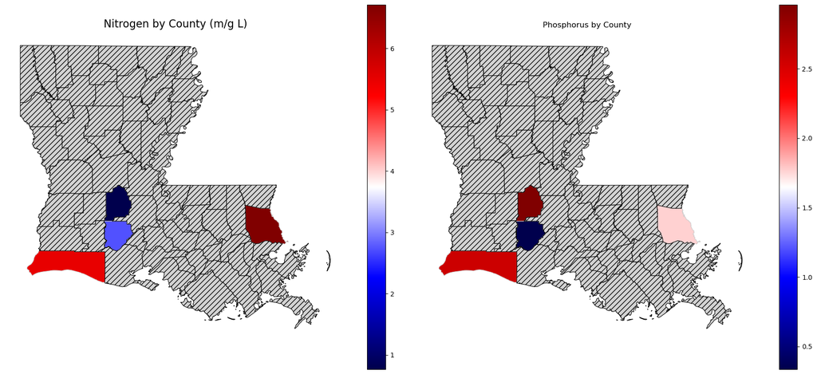

```python
#found this intersting method for moving a column to the end of the frame on stack overflow
la_nitrogen = la_nitrogen[[c for c in la_nitrogen.columns if c != 'geometry'] + ['geometry']]

print(tabulate(la_nitrogen[:10], headers='keys', tablefmt="Github"))

#pass our newly seperated frame to be plotted using the above function
nitrogen_plotter(la_nitrogen)
```

## Not enough data. Only 4 parishes represented...

#### This is very unfortunate, a more ample dataset would be incredibly useful, but ultimately this dataset is poorly documented and sparse of data.

#### Lets take a look at something else, the following dataset has been scrapped from the Environmental Protection Agencies' website and posted to kaggle (https://www.kaggle.com/datasets/sogun3/uspollution)

#### It provides the readings of many common pollutants like carbon, sulphur, and nitrogen, and has a massive amount of entries compared to the previous dataset.

#### Let's take a look at this other dataset:

```python
df_pollution = pd.read_csv(os.path.join(cwd, 'data', 'pollution_us_2000_2016.zip'), encoding='latin1')

#isolate on Lousiana
louisiana_pollution = df_pollution[df_pollution["State"] == 'Louisiana']

print(tabulate(louisiana_pollution.head(10), headers='keys', tablefmt="github"))
```

```
|       |   Unnamed: 0 |   State Code |   County Code |   Site Num | Address              | State     | County           | City        | Date Local   | NO2 Units         |   NO2 Mean |   NO2 1st Max Value |   NO2 1st Max Hour |   NO2 AQI | O3 Units          |   O3 Mean |   O3 1st Max Value |   O3 1s…
|-------|--------------|--------------|---------------|------------|----------------------|-----------|------------------|-------------|--------------|-------------------|------------|---------------------|--------------------|-----------|-------------------|-----------|--------------------|--------…
| 54548 |        54548 |           22 |            33 |          9 | 1061-A Leesville Ave | Louisiana | East Baton Rouge | Baton Rouge | 2000-01-01   | Parts per billion |    31.0833 |                  72 |                 18 |        70 | Parts per million |  0.02335  |              0.038 |        …
| 54549 |        54549 |           22 |            33 |          9 | 1061-A Leesville Ave | Louisiana | East Baton Rouge | Baton Rouge | 2000-01-01   | Parts per billion |    31.0833 |                  72 |                 18 |        70 | Parts per million |  0.02335  |              0.038 |        …
| 54550 |        54550 |           22 |            33 |          9 | 1061-A Leesville Ave | Louisiana | East Baton Rouge | Baton Rouge | 2000-01-01   | Parts per billion |    31.0833 |                  72 |                 18 |        70 | Parts per million |  0.02335  |              0.038 |        …
| 54551 |        54551 |           22 |            33 |          9 | 1061-A Leesville Ave | Louisiana | East Baton Rouge | Baton Rouge | 2000-01-01   | Parts per billion |    31.0833 |                  72 |                 18 |        70 | Parts per million |  0.02335  |              0.038 |        …
| 54552 |        54552 |           22 |            33 |          9 | 1061-A Leesville Ave | Louisiana | East Baton Rouge | Baton Rouge | 2000-01-02   | Parts per billion |    10.95   |                  28 |                  0 |        26 | Parts per million |  0.0185   |              0.025 |        …
| 54553 |        54553 |           22 |            33 |          9 | 1061-A Leesville Ave | Louisiana | East Baton Rouge | Baton Rouge | 2000-01-02   | Parts per billion |    10.95   |                  28 |                  0 |        26 | Parts per million |  0.0185   |              0.025 |        …
| 54554 |        54554 |           22 |            33 |          9 | 1061-A Leesville Ave | Louisiana | East Baton Rouge | Baton Rouge | 2000-01-02   | Parts per billion |    10.95   |                  28 |                  0 |        26 | Parts per million |  0.0185   |              0.025 |        …
| 54555 |        54555 |           22 |            33 |          9 | 1061-A Leesville Ave | Louisiana | East Baton Rouge | Baton Rouge | 2000-01-02   | Parts per billion |    10.95   |                  28 |                  0 |        26 | Parts per million |  0.0185   |              0.025 |        …
| 54556 |        54556 |           22 |            33 |          9 | 1061-A Leesville Ave | Louisiana | East Baton Rouge | Baton Rouge | 2000-01-03   | Parts per billion |    10.0833 |                  19 |                 16 |        18 | Parts per million |  0.013792 |              0.02  |        …
| 54557 |        54557 |           22 |            33 |          9 | 1061-A Leesville Ave | Louisiana | East Baton Rouge | Baton Rouge | 2000-01-03   | Parts per billion |    10.0833 |                  19 |                 16 |        18 | Parts per million |  0.013792 |              0.02  |        …
```

## Precautions

#### Before I go and do a bunch of plotting again, lets take a look to make sure this is still a viable approach to the problem.

#### I want to ensure we have diversity in the sampling so that what we base our assumptions on has valid scope.

#### I ideally want samples from all over Louisiana, as many parishes as we can get.

```python
print(len(louisiana_pollution['County']))
print(louisiana_pollution['County'].unique())
print(louisiana_pollution['City'].unique())
```

```
23874
['East Baton Rouge' 'Jefferson']
['Baton Rouge' 'Kenner']
```

## A Lack of diversity kills promise

#### A uselessly small scope of just 2 parishes. 23,000 samples from just 2 parishes!!!

#### I am going to have to pivot away from this unfortunately. We will look into larger scale training.

#### I would have loved to have gotten more data for many counties in Louisiana to compare on a micro scale to the Tulane study. But we can still train on many states or even the whole country. I hope to be able to collect data of my own to make this usable.

#### I personally feel that the scope for this can no longer focus on Louisiana, as both of the pollution sets we have identified only contain a handful of parishes. Any conclusion drawn from such a dataset is essentially trivial.

#### We will continue to use this second pollution dataset, as it does indeed contain a massive amount of data and can be used to predict cancer incidence for the counties it does include.

```python
def geomerge(dataframe, features, state_fips):
    """take our frame in, desired features, and the FIPS codes we want to include in the output geoframe
        we can use the FIPS code list to filter for whatever region we want to include
        since this is a right merge on Name and County in the dataframe."""

    #important to remember the default observation of this is counties
    shapefile = os.path.join(cwd, 'county_shapefiles', 'cb_2018_us_county_500k.shp')
    us_counties = gpd.read_file(shapefile)

    #filter only for those counties who are in our FIPS code list
    us_counties = us_counties[us_counties["STATEFP"].isin(state_fips)]

    #merging right, so we drop anythign that does not match on the frames 'County' column
    geo_merged = us_counties.merge(dataframe, left_on="NAME", right_on="County", how="left")

    #dropping any messed up rows/renaming geometry and dropping useless y dim like before
    #geo_merged = geo_merged.dropna(subset=features)
    geo_merged = geo_merged.rename(columns={'geometry_x': 'geometry'})
    geo_merged = geo_merged.drop(columns=['geometry_y'])

    #assign to a variable and set the crs
    geo_merged = gpd.GeoDataFrame(geo_merged, geometry='geometry', crs='EPSG:4326')

    return geo_merged
```

## Another Merge

#### I will merge this new dataset onto our previously created merged_south dataset which contains our cancer rate data.

#### Scroll back to milestone 1 if you are unsure what is going on, I understand this project can be confusing with all of the coordinate data being used.

```python
df_pollution.columns = df_pollution.columns.str.replace(' ', '_')

#take all of these as averages grouped by county
N02_mean = df_pollution.groupby("County").NO2_Mean.mean()
O3_Mean = df_pollution.groupby("County").O3_Mean.mean()
S02_Mean = df_pollution.groupby("County").SO2_Mean.mean()
CO_Mean = df_pollution.groupby("County").CO_Mean.mean()

#join them all together
pollution_means = pd.concat([N02_mean, O3_Mean, S02_Mean, CO_Mean], axis=1).reset_index()
merged_final_southern_states = merged_south.merge(pollution_means, on="County", how="left")

features = ["NO2_Mean", "O3_Mean", "SO2_Mean", "CO_Mean",
             "incidenceRate", "deathRate", "avgDeathsPerYear"]

merged_final_southern_states = merged_final_southern_states.dropna()
```

## Finally we have all of our data cleaned and ready to visualize (and eventually train on)

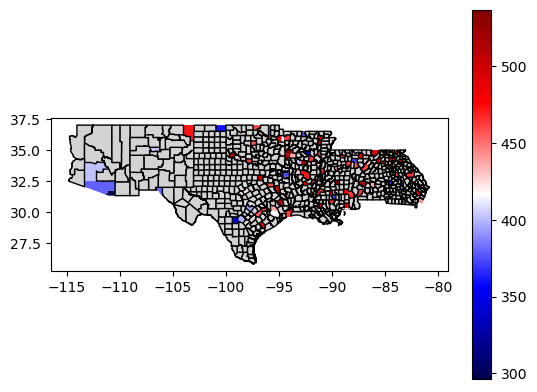

```python
southern_fips = ['01','04','05','13','22','28','40','35','48']

#call our new geomerge function with our cancer data, desired features, and our fips codes
geo_merged = geomerge(merged_final_southern_states, features, state_fips=southern_fips)

geo_merged.plot(column= "incidenceRate", cmap="seismic", legend=True,
missing_kwds={
                "color": "lightgrey",
                "edgecolor": "black",
                "label": "No data"})

plt.show()
```

## The Bigger Scope

#### Ok, so we have established that the smaller scope is not viable due to poor sampling diversity.

#### We may still have potential if we consider the massive amount of samples we have, especially if we open up to considering the whole country.

#### You may wonder what all of the strings are below, each state has its own respective FIPS code, a unique numeric value to identify a state. I hand compiled this dictionary from the US Survey website.

#### I also excluded Hawaii to keep the scale of our graphs easily manageable

```python
state_fips = {
    'Alabama': '01', 'Arizona': '04', 'Arkansas': '05',
    'California': '06', 'Colorado': '08', 'Connecticut': '09', 'Delaware': '10',
    'Florida': '12', 'Georgia': '13', 'Idaho': '16',
    'Illinois': '17', 'Indiana': '18', 'Iowa': '19', 'Kansas': '20',
    'Kentucky': '21', 'Louisiana': '22', 'Maine': '23', 'Maryland': '24',
    'Massachusetts': '25', 'Michigan': '26', 'Minnesota': '27',
    'Mississippi': '28', 'Missouri': '29', 'Montana': '30', 'Nebraska': '31',
    'Nevada': '32', 'New Hampshire': '33', 'New Jersey': '34', 'New Mexico': '35',
    'New York': '36', 'North Carolina': '37', 'North Dakota': '38', 'Ohio': '39',
    'Oklahoma': '40', 'Oregon': '41', 'Pennsylvania': '42', 'Rhode Island': '44',
    'South Carolina': '45', 'South Dakota': '46', 'Tennessee': '47',
    'Texas': '48', 'Utah': '49', 'Vermont': '50', 'Virginia': '51',
    'Washington': '53', 'West Virginia': '54', 'Wisconsin': '55', 'Wyoming': '56'
}

merged_states = []

for state, fips in state_fips.items():
    #for every state, append a list of frames with pollution and incidence rate
    #metrics from our function above
    df = state_countyMetrics(state, fips)
    merged_states.append(df)

#concatenate all of our state frames onto each other to make a super frame
merged_all_states = pd.concat(merged_states, ignore_index=True)

#remeber that pollution means is taken above - left join onto our county data by county
merged_all_states = merged_all_states.merge(pollution_means, on="County", how="left")
merged_all_states = merged_all_states.dropna()
```

## A usable amount of data

#### While I am still quite frustrated by the poor sample size, this dataset seems feasible if we train on the entire state.

#### We will build a regressor model, training and testing on both the greater south and the whole country.

#### In Milestone 2 I did not document this part well, and did not do a good job at framing the data. Below I have added labels and clamped the data by quantile to eliminate outlier noise.

#### There must have been some county somewhere with an insane incidence rate that made the whole graph blue and I was careless with the presentation of the data.

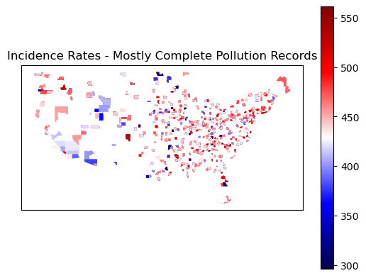

```python
#all values in our above dictionary
all_fips = list(state_fips.values())

geo_merged_all = geomerge(merged_all_states, features, state_fips=all_fips)
upper_limit = geo_merged_all["incidenceRate"].quantile(0.995)
geo_merged_all["incidenceRate_clamped"] = geo_merged_all["incidenceRate"].clip(upper=upper_limit)

ax = geo_merged_all.plot(column="incidenceRate_clamped",
                    cmap="seismic",
                    legend=True)

plt.tight_layout
ax.set_title("Incidence Rates - Mostly Complete Pollution Records")
ax.set_xticks([])
ax.set_yticks([])
ax.set_xlabel("")
ax.set_ylabel("")
plt.show()
```

## Milestone 3: How about we train a KNN regressor and evaluate it's performance between regions.

#### We could perform either logistic regression or linear regression. I think KNN would be interesting, and allow us to tune our model like in lab 10.

#### Going to build a model to predict incidence rate by pollution levels. We will use the data we have inspected so far from the greater south to predict for the entire nation.

#### Our model will have peeked at some of our final testing data, but this dataset is so sparse I feel it is neccesary.

#### Let's build a 10 nearest neighbors regressor to predict cancer incidence rates based on reported pollution levels from the south dataset we already have. If this proves fruitful, we can expand our training scope to the entire nation.

```python
predictions = []
actuals = []

features = ["NO2_Mean", "O3_Mean", "SO2_Mean", "CO_Mean"]
target = "incidenceRate"

#split train and test 80/20
X_train, X_test, y_train, y_test = train_test_split(
    merged_final_southern_states[features],
    merged_final_southern_states[target],
    test_size=0.2,
    random_state=444
)

#10nn regression model
model = KNeighborsRegressor(n_neighbors=10)
model.fit(X_train, y_train)

#loop through the partitioned test set
for i in range(len(X_test)):
    try:
        X_row = X_test.iloc[i].to_frame().T
        pred = model.predict(X_row)[0]
        actual = y_test.iloc[i]

        predictions.append(pred)
        actuals.append(actual)

    except Exception as e:
        print(f"Error on index {i}: {e}")
        pass

actuals_arr = np.array(actuals)
preds_arr = np.array(predictions)

#mean absolute percentage error (MAPE)
mape = np.mean(np.abs((actuals_arr - preds_arr) / actuals_arr)) * 100

#manhattan distance (MAE) or arithmetic average of absolute errors  ors
mae = mean_absolute_error(actuals_arr, preds_arr)

print(f"Mean Absolute Error (MAE): {mae:.2f}")
print(f"Mean Absolute Percentage Error (MAPE): {mape:.2f}%")
```

```
Mean Absolute Error (MAE): 44.69
Mean Absolute Percentage Error (MAPE): 10.10%
```

## Let's test our model by predicting on all counties.

#### We have a massive amount of data entries, they are simply too concentrated on only a few counties.

#### Since we already have a dataset for the regional south, let's test it's accuracy by training on it, and then predicting for the whole country.

#### Below we will prepare a Geodataframe, which contains both coordinates for plotting as well as our numeric data for incidence rates and pollution.

#### Note that we simply join one of our shape files (containing the image representation of our counties) onto our 'merged_final_southern_states' frame which contains our current numeric data.

```python
#make a prediction and insert it into our dataframe for later
geo_merged_all_drop = geo_merged_all.dropna().copy()
geo_merged_all_drop["predicted_incidence"] = model.predict(geo_merged_all_drop[features])
```

## Trained on the South -> Predicting on the whole nation

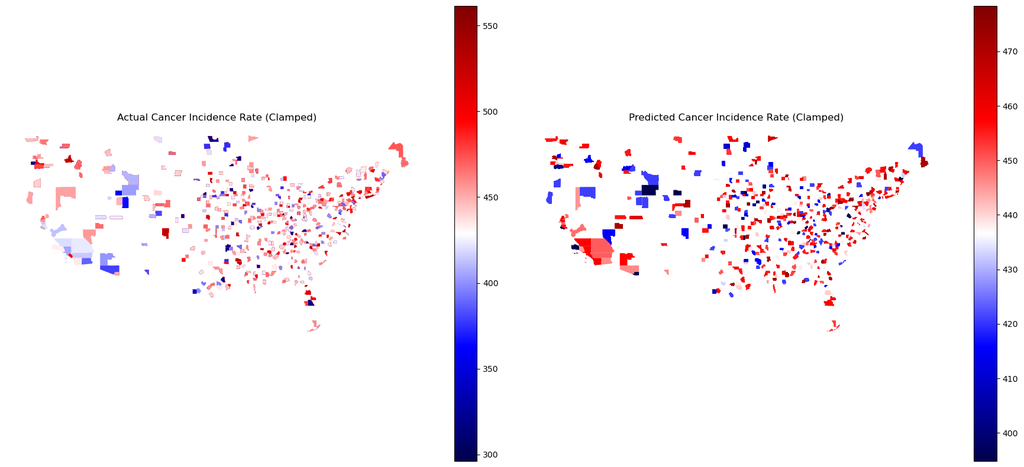

```python
fig, axes = plt.subplots(1, 2, figsize=(18, 8))

upper_limit = geo_merged_all_drop["incidenceRate"].quantile(0.995)

geo_merged_all_drop["incidenceRate_clamped"] = geo_merged_all_drop["incidenceRate"].clip(upper=upper_limit)
geo_merged_all_drop["predicted_incidence_clamped"] = geo_merged_all_drop["predicted_incidence"].clip(upper=upper_limit)

geo_merged_all_drop.plot(column="incidenceRate_clamped", cmap="seismic", legend=True, ax=axes[0])
axes[0].set_title("Actual Cancer Incidence Rate (Clamped)")
axes[0].axis("off")

geo_merged_all_drop.plot(column="predicted_incidence_clamped", cmap="seismic", legend=True, ax=axes[1])
axes[1].set_title("Predicted Cancer Incidence Rate (Clamped)")
axes[1].axis("off")

plt.tight_layout()
plt.show()
```

## Lets train on the whole nation, and predict on individual states.

#### Again, this will cheat slightly, but is only to serve as a baseline for future evaluation.

#### I will be gathering more samples myself after graduation. I love to spend time on the water and will be doing so for a living after graduation so can do so at will. I will be kayaking and camping in the north of Louisana, and will sample the soil and river's for these pollutants.

```python
def trainTest_model(k, X_train, X_test, y_train, y_test):
    #knn regression model
    model = KNeighborsRegressor(n_neighbors = k)
    model.fit(X_train, y_train)

    predictions = []
    actuals = []

    #loop through the partitioned test set
    for i in range(len(X_test)):
        try:
            X_row = X_test.iloc[i].to_frame().T
            pred = model.predict(X_row)[0]
            actual = y_test.iloc[i]

            predictions.append(pred)
            actuals.append(actual)

        except Exception as e:
            print(f"Error on index {i}: {e}")
            pass

    actuals_arr = np.array(actuals)
    preds_arr = np.array(predictions)

    #mean absolute percentage error (MAPE)
    mape = np.mean(np.abs((actuals_arr - preds_arr) / actuals_arr)) * 100

    #manhattan distance (MAE) or arithmetic average of absolute errors
    mae = mean_absolute_error(actuals_arr, preds_arr)

    r2 = r2_score(actuals, predictions)

    return model, mape, mae, r2
```

## Parameter and Model Evalaution

#### This is likely a function of overfitting, and can be artifically limited by simply restricting N

```python
model_list = []
mape_list = []
mae_list = []
r2_list = []
k_values = []

best_mae = 10000
best_mape = 100.00
best_model = KNeighborsRegressor
best_k = 0

#split train and test 80/20
X_train, X_test, y_train, y_test = train_test_split(
    merged_all_states[features],
    merged_all_states[target],
    test_size=0.2,
    random_state=444)

#this is my answer from lab 10 - simply loop over a fixed range and select the best model
#according to some criteria, and the respective k value at the time of achieving this best
for k in range(1, 200):
    model, mape, mae, r2 = trainTest_model(k, X_train, X_test, y_train, y_test)

    #capture these best values and use them for our k decision
    if mae < best_mae:
        best_mae = mae
        best_model = model
        best_k = k

    if mape < best_mape:
        best_mape = mape

    mape_list.append(mape)
    mae_list.append(mae)
    r2_list.append(r2)
    k_values.append(k)
```

## We have our best MAE and MAPE k value, and can use this to make a decision on our ideal K for prediction.

#### I will keep this simple and use the best_k value captured on the back of the MAE value. But you could tune this however you like.

```
Best Average Error: 30.823744871315796 at K: 190
```

[figure not shown]

```python
fig, (ax1,ax2) = plt.subplots(1,2)
fig.set_figheight(10)
fig.set_figwidth(40)

#probably a fancier way of doing this iteratively but manually specifying each subplot works
ax1.plot(k_values, r2_list, linewidth=5, color='red')
ax1.set_xlabel('K-Value')
ax1.set_ylabel('MAPE')
ax1.set_title('Mean Absolute Percentage Error')

#probably a fancier way of doing this iteratively but manually specifying each subplot works
ax2.plot(k_values, mae_list, linewidth=5, color='blue')
ax2.set_xlabel('K-Value')
ax2.set_ylabel('MAE')
ax2.set_title('Mean Absolute Error')

print(f"Best Average Error: {best_mae} at K: {best_k}")
```

## Trained on whole country -> Predict on single state

#### The below function will predict on a single state, we can visualize our model's capability on a local isolated region.

#### We essentially 'go both ways' analyzing the data's ability to scale up or down in scale.

```python
def statePredictor(state, fipsCode, model):
    merged_State = state_countyMetrics(state, fipsCode)
    merged_State = merged_State.merge(pollution_means, on="County", how="left")
    us_counties = gpd.read_file(os.path.join(cwd, 'county_shapefiles', 'cb_2018_us_county_500k.shp'))
    us_counties = us_counties[us_counties["STATEFP"] == fipsCode]

    geo_merged = us_counties.merge(merged_State, left_on="NAME", right_on="County", how="left")

    geo_merged = geo_merged.dropna(subset=features)

    #make a prediction and insert it into our dataframe for later
    geo_merged["predicted_incidence"] = model.predict(geo_merged[features])

    #rename these dummy columns to clean things up
    geo_merged = geo_merged.rename(columns={'geometry_x': 'geometry'})
    geo_merged = geo_merged.drop(columns=['geometry_y'], errors='ignore')

    #geo_merged = geo_merged[[col for col in geo_merged.columns if not col.endswith('_y')]]
    geo_merged = gpd.GeoDataFrame(geo_merged, geometry='geometry', crs='EPSG:4326')

    fig, axes = plt.subplots(1, 2, figsize=(18, 8))

    geo_merged.plot(column="incidenceRate", cmap="seismic", legend=True, ax=axes[0])
    axes[0].set_title("Actual Cancer Incidence Rate")
    axes[0].axis("off")

    geo_merged.plot(column="predicted_incidence", cmap="seismic", legend=True, ax=axes[1])
    axes[1].set_title("Predicted Cancer Incidence Rate (Model)")
    axes[1].axis("off")

    plt.tight_layout()
    plt.show()
```

## Experimenting

#### Below you see the counties available to us in a variety of states, and their respective predictions.

#### If these are accurate, we can determine that for every sample gathered per county, we have a model capable of determining the cancer rate accurately.

## Florida

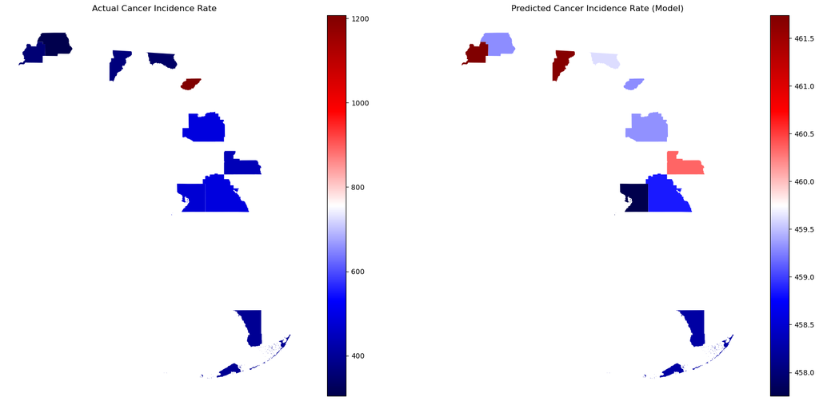

```python
statePredictor("Florida" , "12", best_model)
```

## Texas

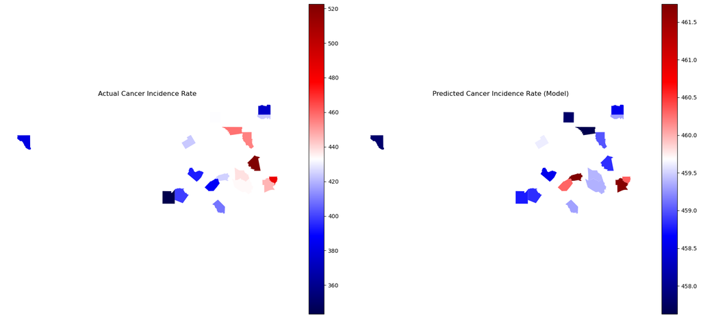

```python
statePredictor("Texas" , "48", best_model)
```

## California

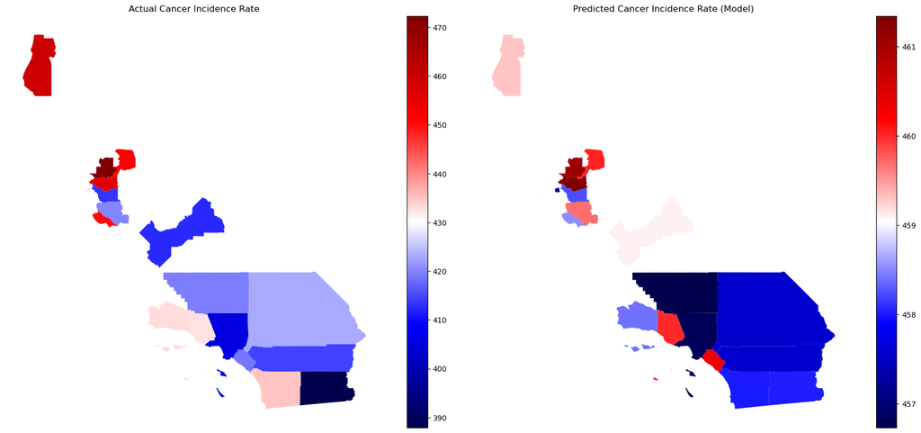

```python
statePredictor("California" , "06", best_model)
```

## New York

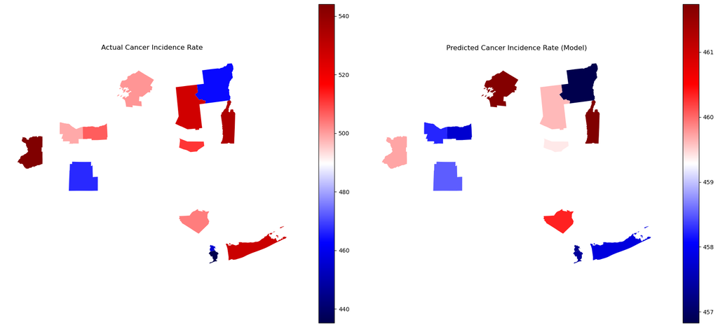

```python
statePredictor("New York" , "36", best_model)
```

#### With greater data sampling, a stronger correlation could be built and visualized. It seems that these are for only 90 counties, often a handful per state. But the given model can be scaled to any size of dataset.

#### As I collect my own samples on my travels, I will use this model to try and determine the cancer rates of that region, comparing to the actual recorded levels.

#### Remeber the Nitrogen graph from above....

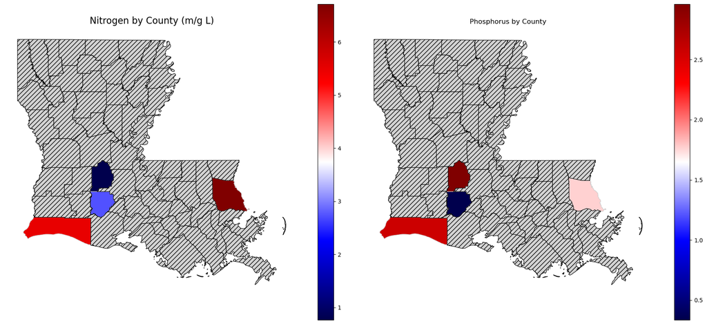

```python
nitrogen_plotter(la_nitrogen)
```

#### I would like to fill in the holes here myself, measuring a variety of pollutants from the entire state. Using the model created here, or one very similair to determine the true situation.

#### Unfortunately, that lies in the future and outside of the scope for this class.

```python
#for converting this to an html asset to display on github site
from nbconvert import HTMLExporter
import nbformat

current_file = os.path.join(cwd, 'finalMilestone_arturoAltamirano.ipynb')
with open(current_file) as f:
    notebook = nbformat.read(f, as_version=4)

html_exporter = HTMLExporter()
html_exporter.theme = 'dark'
(body, resources) = html_exporter.from_notebook_node(notebook)

output_file = os.path.join(cwd, 'currentMilestone.html')
with open(output_file, "w", encoding="utf-8") as f:
    f.write(body)
```